Universidad El Bosque

Diseño de Experimentos

Sesión 2 de 2 · 90 min

# Cuadros latinos y cuadrados grecolatinos

Comparar, diagnosticar, recuperar un dato y estirar el cuadro

ComparacionesPotenciaDato faltanteCrossoverGrecolatinoCiencia de datos

**Javier Mauricio Sierra**

Universidad El Bosque

Diseño de Experimentos

Capítulo 6 · Cuadros latinos y cuadrados grecolatinos

Estimación y comparaciones

Diagnóstico y dato faltante

Réplicas y crossover

El cuadrado grecolatino

Los límites de la ortogonalidad

Ciencia de datos

Cierre y práctica

Hoja de ruta

## Lo que vamos a construir hoy

Objetivo de la sesión

Comparar tratamientos y dimensionar un cuadro latino, diagnosticarlo con pocos grados de libertad, estimar un dato perdido y reconocer las extensiones del cuadro: réplicas, crossover, grecolatino y sus límites.

ComparacionesPotenciaDato faltanteCrossoverGrecolatinoCiencia de datos

2 / 28

Universidad El Bosque

Diseño de Experimentos

Capítulo 6 · Cuadros latinos y cuadrados grecolatinos

Estimación y comparaciones

Diagnóstico y dato faltante

Réplicas y crossover

El cuadrado grecolatino

Los límites de la ortogonalidad

Ciencia de datos

Cierre y práctica

01

## Estimación y comparaciones

Cada media de tratamiento promedia \(p\) celdas: una en cada fila y una en cada columna.

Leer en el material: 6.6 Estimación, comparaciones y cuánto cuadro hace falta

3 / 28

Estimación y comparaciones

## D es la formulación más rápida y B la más lenta: las separan 9.6 unidades

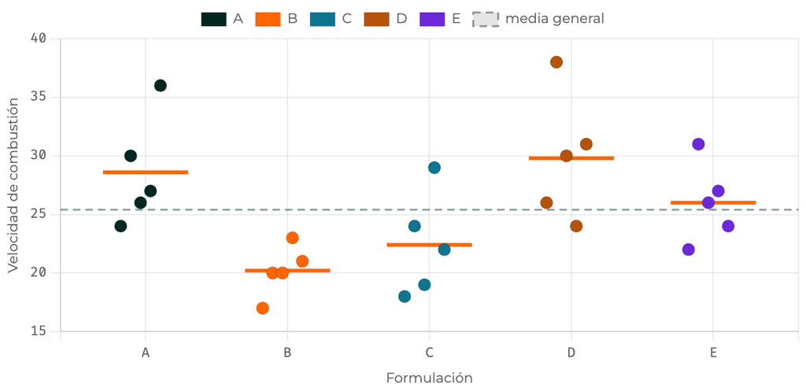

Velocidad de combustión por formulación, con la media de cada una y la media general

|  | Media | Efecto |
| --- | --- | --- |
| A | 28.6 | +3.2 |
| B | 20.2 | −5.2 |
| C | 22.4 | −3.0 |
| D | 29.8 | +4.4 |
| E | 26.0 | +0.6 |

Lote y operador se cancelan en cada media: \(\text{EE} = \sqrt{MS_E/p} = 1.461\).

¿Cuáles de estas diferencias son reales?

Capítulo 6 · Cuadros latinos y cuadrados grecolatinosDiseño de Experimentos · UnBosque4 / 28

Estimación y comparaciones

## Las comparaciones del capítulo 3 valen con \(p\) en lugar de \(n\) y 12 gl

$$\text{EE de una diferencia} = \sqrt{2\,MS_E/p} = \sqrt{2(10.667)/5} = 2.066$$

| Procedimiento | Cuantil, 12 gl | × 2.066 = umbral |
| --- | --- | --- |
| LSD | \(t_{0.025} = 2.179\) | 4.501 |
| Tukey | \(q_{0.05}(5, 12)/\sqrt{2} = 3.187\) | 6.584 |
| Bonferroni | \(t_{0.0025} = 3.428\) | 7.082 |

Dos medias difieren si su distancia supera el umbral. Cuantas más comparaciones protege el método, más alto queda.

Capítulo 6 · Cuadros latinos y cuadrados grecolatinosDiseño de Experimentos · UnBosque5 / 28

Pregunta para la clase

## ¿Qué pares separan el LSD y Tukey?

Diferencias absolutas entre las medias de formulación:

|  | B | C | D | E |
| --- | --- | --- | --- | --- |
| A | 8.4 | 6.2 | 1.2 | 2.6 |
| B |  | 2.2 | 9.6 | 5.8 |
| C |  |  | 7.4 | 3.6 |
| D |  |  |  | 3.8 |

Umbrales: **LSD 4.501**, **Tukey 6.584**.

Respuesta

Tukey separa **D–B** (9.6), **A–B** (8.4) y **D–C** (7.4). El LSD, más liberal, añade **A–C** (6.2) y **E–B** (5.8). Tukey exige más porque protege las diez comparaciones a la vez.

Capítulo 6 · Cuadros latinos y cuadrados grecolatinosDiseño de Experimentos · UnBosque6 / 28

Estimación y comparaciones

## Subir el orden del cuadro ayuda despacio; un efecto más grande, mucho más deprisa

Potencia exacta con la F no central

```
potencia_latino <- function(p, delta, sigma = 1, alpha = 0.05) {
  gl_e   <- (p - 2) * (p - 1)
  tau    <- delta * seq(-1, 1, length.out = p)   # patrón lineal
  lambda <- p * sum(tau^2) / sigma^2
  pf(qf(1 - alpha, p - 1, gl_e), p - 1, gl_e,
     ncp = lambda, lower.tail = FALSE)
}
round(sapply(3:7, function(p) potencia_latino(p, 0.5)), 6)
#> [1] 0.084965 0.133582 0.183866 0.239109 0.300664

round(sapply(c(0.25, 0.5, 0.75, 1),
             function(d) potencia_latino(5, d)), 6)
#> [1] 0.078906 0.183866 0.384698 0.636746
```

- \(\delta\): el efecto extremo en unidades de \(\sigma\), en patrón lineal de \(-\delta\) a \(\delta\)
- \(\delta = 0.5\): de \(p = 3\) a \(p = 7\), de **0.085** a **0.301**
- \(p = 5\): de \(\delta = 0.25\) a \(\delta = 1\), de 0.079 a **0.637**

Ninguno llega al 0.80 habitual. Y \(p\) casi nunca se elige: es el número de tratamientos.

Capítulo 6 · Cuadros latinos y cuadrados grecolatinosDiseño de Experimentos · UnBosque7 / 28

Idea clave

## Un cuadro latino sin replicar solo ve los efectos grandes; a los pequeños es casi ciego

Si \(p \le 4\), **replica el cuadro** o usa otro diseño.

Capítulo 6 · Cuadros latinos y cuadrados grecolatinosDiseño de Experimentos · UnBosque8 / 28

Universidad El Bosque

Diseño de Experimentos

Capítulo 6 · Cuadros latinos y cuadrados grecolatinos

Estimación y comparaciones

Diagnóstico y dato faltante

Réplicas y crossover

El cuadrado grecolatino

Los límites de la ortogonalidad

Ciencia de datos

Cierre y práctica

02

## Diagnóstico y dato faltante

Perder un dato en un cuadro latino duele más que en un DBCA.

Leer en el material: 6.7 Diagnóstico y el dato que falta

9 / 28

Diagnóstico y dato faltante

## Con doce grados de libertad, \(p = 0.058\) no dice «son normales»

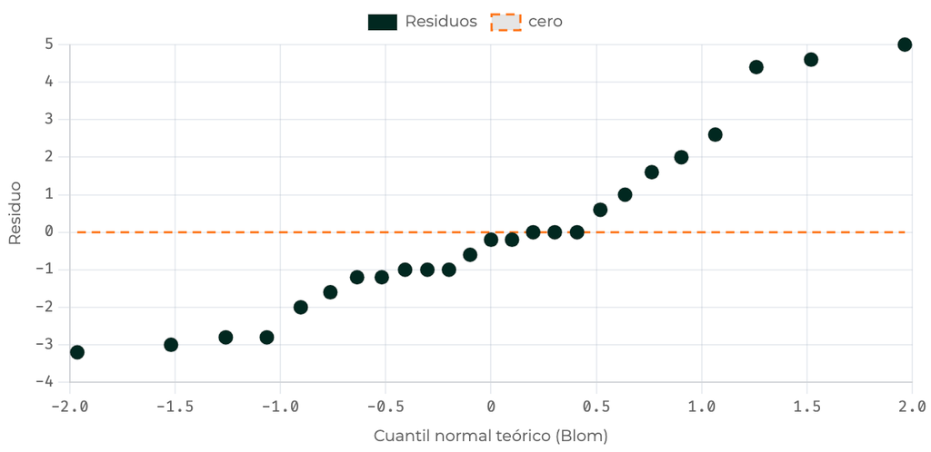

Gráfico de probabilidad normal de los residuos del propelente, con posiciones de Blom

- Residuos entre −3.2 y 5.0: el mayor es 1.5 veces \(\sqrt{MS_E} = 3.27\), ningún atípico
- Shapiro–Wilk: \(W = 0.922\), \(p = 0.058\)
- Lo honesto: **no hay evidencia fuerte** contra la normalidad

Con 12 gl la prueba tiene poca potencia: no rechazar no es confirmar. Se sigue con el ANOVA, sin afirmar que los errores sean normales.

Capítulo 6 · Cuadros latinos y cuadrados grecolatinosDiseño de Experimentos · UnBosque10 / 28

Diagnóstico y dato faltante

## Si falta una observación, la ecuación 4.28 la estima

$$x = \frac{p\,(y'_{i\cdot\cdot} + y'_{\cdot j\cdot} + y'_{\cdot\cdot k}) - 2y'_{\cdots}}{(p-2)(p-1)}$$

En los ingredientes (lotes × días, EG-21) se pierde el lote 3, día 4: tratamiento \(E\), que valía 1. Con los totales de lo que sí hay —lote 28, tratamiento 15, día 24 y total 146—:

$$x = \frac{5\,(28 + 15 + 24) - 2(146)}{12} = 3.583$$

El análisis sigue con la celda rellena y **un gl menos** en el error: 11 en vez de 12.

Capítulo 6 · Cuadros latinos y cuadrados grecolatinosDiseño de Experimentos · UnBosque11 / 28

Diagnóstico y dato faltante

## El valor de la ecuación 4.28 es el que minimiza \(SS_E\)

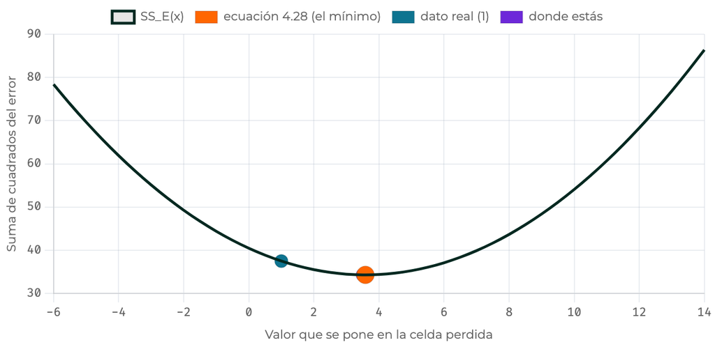

La suma de cuadrados del error en función del valor que se pone en la celda perdida

El dato real (1) queda a un lado; el estimado (3.583) está en el fondo de la parábola, con \(SS_E = 34.32\).

La fórmula no adivina el dato perdido: pone el valor que mejor encaja en el modelo. Qué consecuencias tiene, en la pregunta siguiente.

Capítulo 6 · Cuadros latinos y cuadrados grecolatinosDiseño de Experimentos · UnBosque12 / 28

Pregunta para la clase

## Faltando un dato, ¿cuáles son correctas?

Completo, con el dato real: \(F = 11.309\) (12 gl). Rellenando la celda: \(F = 10.310\) (11 gl). Exacto, con las 24 que hay: \(F = 9.667\) (11 gl).

1. El valor de la ecuación 4.28 minimiza \(SS_E\), y por eso el análisis aproximado sale optimista.
2. Hay que descontar un grado de libertad del error, y aun así queda algo de sesgo.
3. Sin esa celda, el tratamiento deja de ser ortogonal y el análisis exacto ajusta su suma de cuadrados.
4. La diferencia entre 11.309 y 9.667 es despreciable en la práctica.

1, 2 y 3

1: es el fondo de la parábola. 2: aun con 11 gl, el 10.310 queda por encima del exacto. 3: la \(E\) ya no está en todas las filas y columnas. La 4 no: es un 15 % del estadístico por una observación de veinticinco.

Capítulo 6 · Cuadros latinos y cuadrados grecolatinosDiseño de Experimentos · UnBosque13 / 28

Universidad El Bosque

Diseño de Experimentos

Capítulo 6 · Cuadros latinos y cuadrados grecolatinos

Estimación y comparaciones

Diagnóstico y dato faltante

Réplicas y crossover

El cuadrado grecolatino

Los límites de la ortogonalidad

Ciencia de datos

Cierre y práctica

03

## Réplicas y crossover

Con \(p\) pequeño hay que replicar el cuadro. Con \(p = 2\) y personas, eso se llama crossover.

Leer en el material: 6.8 Réplicas de cuadros latinos y el diseño crossover

14 / 28

Réplicas y crossover

## Al replicar, los grados de libertad del error dependen de qué se repite

| Caso | Filas | Columnas | gl del error | \(p = 5,\ n = 2\) |
| --- | --- | --- | --- | --- |
| 1 | las mismas | las mismas | \((p-1)[n(p+1)-3]\) | 36 |
| 2 | las mismas | nuevas | \((p-1)(np-2)\) | 32 |
| 3 | nuevas | nuevas | \((p-1)[n(p-1)-1]\) | 28 |

Con dos cuadros de orden 5, el error pasa de 12 gl a 28–36: replicar compra gl, y cada fila o columna nueva se paga con algunos.

Errata de la tabla 4.15, caso 2

Imprime \((p-1)(np-1)\). Con \(p = 5\) y \(n = 2\), los gl de la propia tabla suman **53** contra un total de **49**.

Capítulo 6 · Cuadros latinos y cuadrados grecolatinosDiseño de Experimentos · UnBosque15 / 28

Réplicas y crossover

## En el crossover, la \(t\) ingenua sobre las diferencias pierde el efecto que el ANOVA ve

Doce usuarios completan una tarea con dos versiones de una interfaz, y se miden los segundos. La mitad va A→B y la otra mitad B→A: filas = periodo, columnas = usuario, letras = versión.

| Análisis | Estimador | \(t^2\) | \(p\) |
| --- | --- | --- | --- |
| \(t\) sobre las 12 diferencias | 2.255 | 4.778 | 0.051 |
| Promediando las dos secuencias | 2.255 | **6.869** | **0.026** |

Los dos estiman lo mismo; el correcto saca el efecto de periodo del error, y su \(t^2\) es la \(F\) del ANOVA. Con la ingenua se habría concluido que las versiones no difieren.

Capítulo 6 · Cuadros latinos y cuadrados grecolatinosDiseño de Experimentos · UnBosque16 / 28

Universidad El Bosque

Diseño de Experimentos

Capítulo 6 · Cuadros latinos y cuadrados grecolatinos

Estimación y comparaciones

Diagnóstico y dato faltante

Réplicas y crossover

El cuadrado grecolatino

Los límites de la ortogonalidad

Ciencia de datos

Cierre y práctica

04

## El cuadrado grecolatino

Un tercer factor perturbador: se superpone un segundo cuadro, ortogonal al primero.

Leer en el material: 6.9 El cuadrado grecolatino: tres bloqueos

17 / 28

El cuadrado grecolatino

## Con el montaje de prueba como tercer bloqueo, el \(MS_E\) baja de 10.67 a 8.25

|  | Op. 1 | Op. 2 | Op. 3 | Op. 4 | Op. 5 |
| --- | --- | --- | --- | --- | --- |
| Lote 1 | Aα 24 | Bγ 20 | Cε 19 | Dβ 24 | Eδ 24 |
| Lote 2 | Bβ 17 | Cδ 24 | Dα 30 | Eγ 27 | Aε 36 |
| Lote 3 | Cγ 18 | Dε 38 | Eβ 26 | Aδ 27 | Bα 21 |
| Lote 4 | Dδ 26 | Eα 31 | Aγ 26 | Bε 23 | Cβ 22 |
| Lote 5 | Eε 22 | Aβ 30 | Bδ 20 | Cα 29 | Dγ 31 |

- Letra griega: el montaje. Cada una, una vez por fila, por columna **y con cada latina**
- Lotes (68), operadores (150) y formulaciones (330) **no cambian**
- El error se parte: \(128 = 62 + 66\) y \(12 = 4 + 8\) gl, así que \(MS_E = 66/8 = 8.25\)
- \(F\) de formulaciones: de 7.73 a **10.00**

El montaje se lleva \(62/4 = 15.5\) por gl, más que los 10.67 del error: por eso compensa.

Capítulo 6 · Cuadros latinos y cuadrados grecolatinosDiseño de Experimentos · UnBosque18 / 28

Pregunta para la clase

## Con un cuarto factor, el valor \(p\) pasa de 0.038 a 0.167. ¿Qué pasó?

Cuatro métodos de ensamblaje en un cuadro latino \(4 \times 4\) (filas: orden de ensamblaje; columnas: operador): \(SS_E = 35.0\) con 6 gl, \(MS_E = 5.83\) y el método con \(p = 0.038\). Se añade el puesto de trabajo como cuarto factor ortogonal: se lleva \(SS = 7.5\) y el error queda en 27.5 con 3 gl.

El nuevo factor absorbe menos por grado de libertad que el error

\(MS_{\text{puesto}} = 7.5/3 = 2.50 < 5.83\). El \(MS_E\) **sube** a 9.17 aunque su suma de cuadrados baje, y el crítico de la \(F\) pasa de 4.76 a 9.28. **Un bloqueo mejora el error solo si su cuadrado medio supera al \(MS_E\) que ya había.**

Capítulo 6 · Cuadros latinos y cuadrados grecolatinosDiseño de Experimentos · UnBosque19 / 28

Universidad El Bosque

Diseño de Experimentos

Capítulo 6 · Cuadros latinos y cuadrados grecolatinos

Estimación y comparaciones

Diagnóstico y dato faltante

Réplicas y crossover

El cuadrado grecolatino

Los límites de la ortogonalidad

Ciencia de datos

Cierre y práctica

05

## Los límites de la ortogonalidad

Cuando \(p\) es primo caben \(p - 1\) cuadros ortogonales. Con \(p = 6\) no caben ni dos.

Leer en el material: 6.10 Los límites de la ortogonalidad: el orden 6, los MOLS y el hipercuadrado

20 / 28

Los límites de la ortogonalidad

## Con los \(p - 1\) cuadros ortogonales, el error se queda en cero

- Con \(p = 5\), \(L_a[i, j] = (i + a\,j) \bmod 5\) da **cuatro** cuadros mutuamente ortogonales (MOLS), \(a = 1, \dots, 4\); con \(a = 1\) es el cíclico
- Filas, columnas y los cuatro cuadros son seis factores, un **hipercuadrado**: \(6 \times 4 = 24\) gl, **todos** los que hay
- \(SS_E = 0\) a precisión de máquina: no queda denominador para ningún \(F\)

Cada cuadro superpuesto controla un factor más y le quita \(p - 1\) gl al error. Con todos no queda ninguno: hay que replicar o estimar \(\sigma^2\) desde fuera.

Capítulo 6 · Cuadros latinos y cuadrados grecolatinosDiseño de Experimentos · UnBosque21 / 28

Los límites de la ortogonalidad

## No hay grecolatino de orden 6: ninguno de los 9408 cuadros estándar admite otro ortogonal

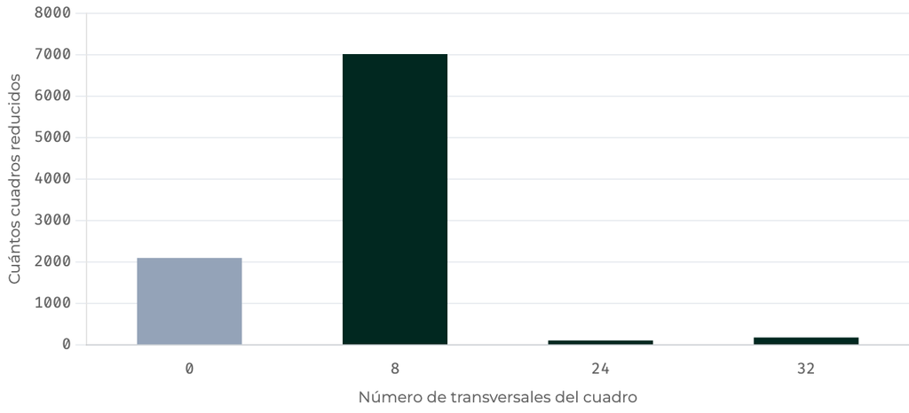

Número de transversales de los 9408 cuadros latinos estándar de orden 6

- **Transversal**: \(p\) celdas, una por fila y una por columna, con las \(p\) letras distintas
- **7308** tienen transversales, hasta 32; nunca hay **seis disjuntas**, que es lo que hace falta para superponer un cuadro griego
- Es el problema de los 36 oficiales de Euler (1782), resuelto por Tarry (1900)

El 6 es una excepción: hay grecolatinos de orden 10, 14, 18… Con seis tratamientos, el tercer bloqueo no cabe en un cuadro.

Capítulo 6 · Cuadros latinos y cuadrados grecolatinosDiseño de Experimentos · UnBosque22 / 28

Universidad El Bosque

Diseño de Experimentos

Capítulo 6 · Cuadros latinos y cuadrados grecolatinos

Estimación y comparaciones

Diagnóstico y dato faltante

Réplicas y crossover

El cuadrado grecolatino

Los límites de la ortogonalidad

Ciencia de datos

Cierre y práctica

06

## Ciencia de datos

Donde ya se usa el cuadro latino sin llamarlo así.

Leer en el material: 6.11 Ciencia de datos: hipercubos, pruebas A/B y comparación de modelos

23 / 28

Ciencia de datos

## Con conjunto y semilla como bloques, los cinco modelos se separan; sin bloquear, no

Cinco modelos de aprendizaje automático y su AUC. Filas: el conjunto de datos; columnas: la semilla; letras: el modelo.

| Análisis de los mismos 25 AUC | \(F\) de modelos | \(p\) |
| --- | --- | --- |
| Cuadro latino | 52.79 | \(1.6 \times 10^{-7}\) |
| Sin bloquear | 2.04 | 0.128 |

Sobre 3000 simulaciones, la potencia es **0.971** con el cuadro y **0.022** sin bloquear. Y son 25 entrenamientos, no los 125 del factorial.

Al comparar modelos, el conjunto y la semilla van al modelo como bloques: las medias no cambian, el error sí.

Capítulo 6 · Cuadros latinos y cuadrados grecolatinosDiseño de Experimentos · UnBosque24 / 28

Ciencia de datos

## La idea del cuadro latino reaparece en el hipercubo, el A/B intra-sujeto y el sudoku

### Hipercubo latino

Cada tramo de cada variable se usa una vez. Con los mismos 25 puntos, el error estándar baja **12.3 veces** frente al azar. Parecido, no igual: no cruza nada.

### A/B intra-sujeto

Es el crossover: con 40 sujetos, el error estándar baja **4.5 veces** frente a dos grupos en paralelo. Su precio es el acarreo: la primera versión deja huella en la segunda.

### Sudoku

Un cuadro latino \(9 \times 9\) con cajas: \(6.67 \times 10^{21}\) rejillas. Sortear uniformemente entre objetos así es difícil.

La idea común es repartir de manera uniforme en cada margen. El A/B y el sudoku son cuadros latinos; el hipercubo solo se les parece.

Capítulo 6 · Cuadros latinos y cuadrados grecolatinosDiseño de Experimentos · UnBosque25 / 28

Universidad El Bosque

Diseño de Experimentos

Capítulo 6 · Cuadros latinos y cuadrados grecolatinos

Estimación y comparaciones

Diagnóstico y dato faltante

Réplicas y crossover

El cuadrado grecolatino

Los límites de la ortogonalidad

Ciencia de datos

Cierre y práctica

07

## Cierre y práctica

Leer en el material: 6.12 Resumen, autoevaluación y lecturas

26 / 28

Cierre y práctica

## Lo que se llevan hoy

- Las comparaciones del capítulo 3 valen con \(p\) en lugar de \(n\) y \((p-1)(p-2)\) gl
- Un cuadro pequeño casi no ve efectos pequeños: si \(p \le 4\), se replica
- Un dato perdido se estima con la ecuación 4.28, y el \(F\) aproximado sale optimista
- Un bloqueo más ayuda solo si su cuadrado medio supera al \(MS_E\) que ya había; uno que existe y se deja fuera del análisis se paga en potencia
- No hay grecolatino de orden 6, y con \(p - 1\) cuadros no quedan gl para el error

Javier Mauricio Sierra

Capítulo 6 · Cuadros latinos y cuadrados grecolatinosDiseño de Experimentos · UnBosque27 / 28

Cierre y práctica

## Práctica en R: los ejercicios guiados

### En clase · EG-22 (a) y (d)

Métodos de ensamblaje: el cuadro \(4 \times 4\) original, y las dos réplicas juntas como cuadros replicados (caso 1).

### En clase · EG-23 (a) y (b)

Qué potencia tiene un cuadro de orden 3 a 7 y cuántas réplicas de un \(4 \times 4\) hacen falta. Parte de `potencia_latino`.

### En casa · EG-21 (c) y (d)

El dato perdido y el día descartado: reproduce en R las cifras de hoy.

### En casa · EG-24

La prueba A/B de hoy: reproduce el crossover y analiza solo la primera sesión.

Capítulo 6 · Cuadros latinos y cuadrados grecolatinosDiseño de Experimentos · UnBosque28 / 28

### Atajos del teclado

[output not shown]

·

00:00

A continuación

Notas